# R Notebook

# Section 3: Descriptive Statistics

```r
df_describe_novelty <- ddply(df,~group,summarise,mean=mean(ln_novelty),sd=sd(novelty))
df_describe_novelty
```

| group | mean | sd |
| --- | --- | --- |
| 0 | 0.3962396 | 0.3640072 |
| 1 | 0.4052544 | 0.3465186 |
| 2 | 0.4771483 | 0.2879949 |
| 3 | 0.5289246 | 0.1914831 |

## Descriptive Statistics ( mean and sd ) for ln_total

```r
df_describe_total <- ddply(df,~group,summarise,mean=mean(ln_total),sd=sd(ln_total))
df_describe_total
```

| group | mean | sd |
| --- | --- | --- |
| 0 | 4.102396 | 1.8851487 |
| 1 | 4.737251 | 1.3639761 |
| 2 | 4.545075 | 1.5945379 |
| 3 | 5.144106 | 0.4274779 |

## Descriptive Statistics ( mean and sd ) for ln_exploration

```r
df_describe_exploration <- ddply(df,~group,summarise,mean=mean(ln_exploration),sd=sd(ln_exploration))
df_describe_exploration
```

| group | mean | sd |
| --- | --- | --- |
| 0 | 0.1662467 | 0.2332004 |
| 1 | 0.1890558 | 0.2442349 |
| 2 | 0.1828346 | 0.2236385 |
| 3 | 0.2372748 | 0.2487672 |

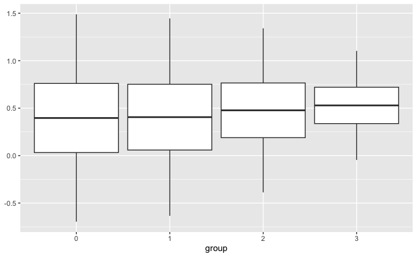

```r
ggplot(df_describe_novelty,aes(x=group))+geom_boxplot(aes(lower=mean-sd,upper=mean+sd,middle=mean,ymin=mean-3*sd,ymax=mean+3*sd),stat="identity")
```

## Boxplots for ln_total with mean and sd.

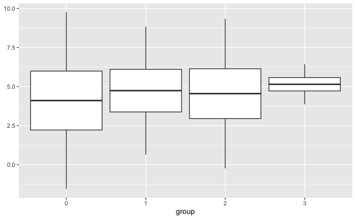

```r
ggplot(df_describe_total,aes(x=group))+geom_boxplot(aes(lower=mean-sd,upper=mean+sd,middle=mean,ymin=mean-3*sd,ymax=mean+3*sd),stat="identity")
```

## Boxplots for ln_exploration with mean and sd.

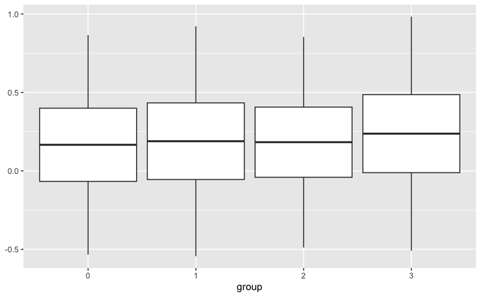

```r
ggplot(df_describe_exploration,aes(x=group))+geom_boxplot(aes(lower=mean-sd,upper=mean+sd,middle=mean,ymin=mean-3*sd,ymax=mean+3*sd),stat="identity")
```

# Section 4: Checking Assumptions

## ggplot visualization for ln_novelty

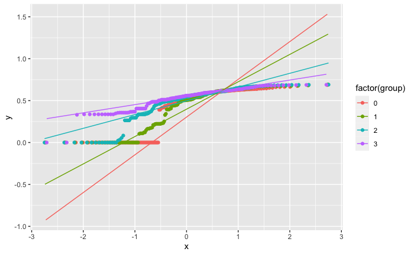

```r
ggplot(df, aes(sample = ln_novelty, colour = factor(group))) +
  stat_qq() +
  stat_qq_line()
```

## ggplot visualization for ln_total

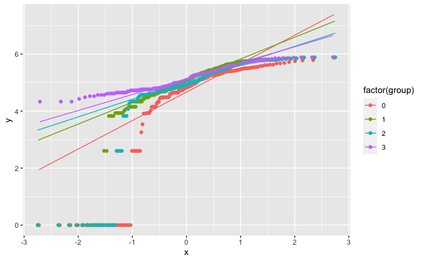

```r
ggplot(df, aes(sample = ln_total, colour = factor(group))) +
  stat_qq() +
  stat_qq_line()
```

## ggplot visualization for ln_exploration

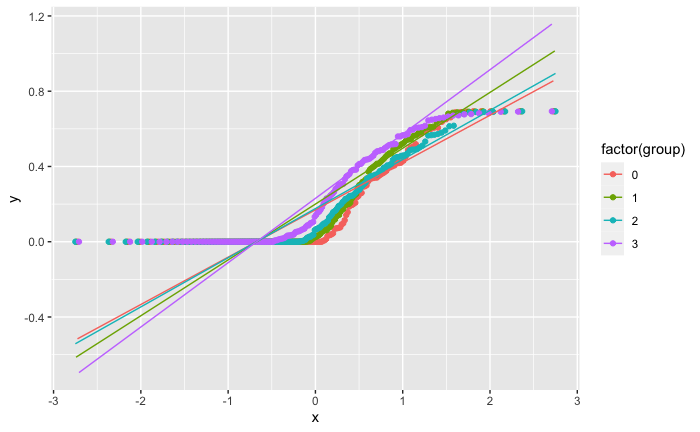

```r
ggplot(df, aes(sample = ln_exploration, colour = factor(group))) +
  stat_qq() +
  stat_qq_line()
```

```r
# spearman correlation between all variables
df_new <- df[, sapply(df, is.numeric)]
cor(df_new, use = "complete.obs", method = "spearman" )
```

The residuals should be approximately normally distributed. The Shapiro-Wilk test can be used to check the normal distribution of residuals. Null hypothesis: data is drawn from a normal distribution.

```r
# output
# Shapiro-Wilk normality test
shapiro.test(resid(aov(ln_novelty ~ group, data = df)))
```

[output not shown]

If the sample size is sufficiently large (n > 30), the moderate departure from normality can be allowed.

In addition, QQ plots and histograms can be used to assess the assumptions of normality

Assumptions of homogeneity of variances The variance should be similar for all genotypes. Bartlett’s test can be used to check the homogeneity of variances. Null hypothesis: samples from populations have equal variances.

```r
bartlett.test(ln_novelty ~ group, data = df)
```

[output not shown]

ANCOVA

```r
anova_test(data = df, formula = ln_novelty ~ group + Q7_Q7_1 + Q7_Q7_2 + Q8_Q8_1 + Q10, type = 3, detailed = TRUE) # type 3 SS should be used in ANCOVA
```

[output not shown]

```r
# Get adjusted means,
adj_means <- emmeans_test(data = df, formula = ln_novelty ~ group, covariate = c(Q7_Q7_1, Q7_Q7_2, Q8_Q8_1, Q10))
get_emmeans(adj_means)
```

[output not shown]

```r
emmeans_test(data = df, formula = ln_novelty ~ group, covariate = c(Q7_Q7_1, Q7_Q7_2, Q8_Q8_1, Q10), p.adjust.method = "fdr")
```

[output not shown]

To know the genotypes with statistically significant differences, I will perform the post-hoc test with the Benjamini-Hochberg FDR method for multiple hypothesis testing at a 5% cut-off

```r
library(car)
mod <- lm(ln_total~ ln_novelty + ln_len_unique, data=df)
vif(mod)
```

```r
df$group <- relevel(df$group, ref = "3")
mod <- lm(ln_added_sum ~ factor(group), data=df)
summary(mod)
```

```r
df$group <- relevel(df$group, ref = "3")
mod <- lm(ln_novelty ~ factor(group), data=df)
summary(mod)
```

```r
df$group <- relevel(df$group, ref = "3")
mod <- lm(ln_total~ factor(group), data=df)
summary(mod)
```

```r
df$group <- relevel(df$group, ref = "3")
mod_exp <- lm(ln_novelty ~ factor(group) + exploration, data=df)
summary(mod_exp)
```

```r
df$group <- relevel(df$group, ref = "3")
mod_exp_int <- lm(ln_novelty ~ factor(group) + exploration + factor(group) * exploration, data=df)
summary(mod_exp_int)
```

```r
anova(mod_exp_int, mod_exp)
```

```r
anova(mod, mod_exp)
```

```r
df$group <- relevel(df$group, ref = "3")
mod <- lm(ln_exploration ~ factor(group), data=df)
summary(mod)
```

```r
library(modelsummary)

`Mean ± SD` <- function(x) {
    sprintf("%.0f ± %.0f", round(mean(x)), round(sd(x)))
}
```

```r
df$group <- relevel(df$group, ref = "3")
mod <- lm(ln_len_unique ~ factor(group), data=df)
summary(mod)
```

```r
tapply(df$ln_len_unique, df$group, summary)
```

```r
df$group <- relevel(df$group, ref = "3")
mod <- lm(ln_total ~ factor(group), data=df)
summary(mod)
```

```r
df$group <- relevel(df$group, ref = "3")
mod <- lm(ln_sim_best ~ factor(group), data=df)
summary(mod)
```

```r
df$group <- relevel(df$group, ref = "3")
mod <- lm(ln_novelty ~ factor(group), data=df)
summary(mod)
```

```r
df$group <- relevel(df$group, ref = "3")
mod2 <- lm(ln_exploration ~ factor(group) + Q7_Q7_1 + Q7_Q7_2 + Q8_Q8_1 + Q10, data=df)
summary(mod2)
```

```r
df$group <- relevel(df$group, ref = "3")
mod3 <- lm(ln_exploration ~  Q7_Q7_1 + Q7_Q7_2 + Q8_Q8_1 + Q10, data=df)
summary(mod3)
```

```r
anova(mod2, mod3)
```

```r
df$group <- relevel(df$group, ref = "3")
mod <- lm(ln_novelty ~ factor(group) + Q7_Q7_1 + Q7_Q7_2 + Q8_Q8_1 + Q10, data=df)
summary(mod)
```

```r
df$group <- relevel(df$group, ref = "3")
mod1 <- lm(ln_novelty ~ factor(group) + Q7_Q7_1 + Q7_Q7_2 + Q8_Q8_1 + Q10, data=df)
summary(mod1)
```

```r
df$group <- relevel(df$group, ref = "3")
mod4 <- lm(ln_novelty ~ Q7_Q7_1 + Q7_Q7_2 + Q8_Q8_1 + Q10 + count, data=df)
summary(mod4)
```

```r
anova(mod1, mod4)
```

```r
library(lmerTest)
fit.lmer <- lmer(ln_novelty ~ factor(group) + ( 1 |phase) , data = df, REML= FALSE)
summary(fit.lmer)
```

```r
library(lmerTest)
fit.lmer <- lmer(ln_exploration ~ factor(group) + ( 1 |phase) , data = df, REML= FALSE)
summary(fit.lmer)
```

```r
library(lmerTest)
fit.lmer <- lmer(ln_exploration ~ factor(group) + ( 1 |phase) + Q7_Q7_1 + Q7_Q7_2 + Q8_Q8_1 + Q10 , data = df, REML= FALSE)
summary(fit.lmer)
```

```r
library(lmerTest)
fit.lmer <- lmer(ln_total ~ factor(group) + ( 1 |phase), data = df, REML= FALSE)
summary(fit.lmer)
```

```r
library(lmerTest)
fit.lmer <- lmer(ln_total ~ factor(group) + ( 1 |phase) + Q7_Q7_1 + Q7_Q7_2 + Q8_Q8_1 + Q10 , data = df, REML= FALSE)
summary(fit.lmer)
```

```r
df$group <- relevel(df$group, ref = "3")
mod <- lm(ln_novelty ~ factor(group) * exploration + Q7_Q7_1 + Q7_Q7_2 + Q8_Q8_1 + Q10, data=df)
summary(mod)
```

```r
df$group <- relevel(df$group, ref = "3")
mod <- lm(ln_novelty ~ factor(group) + exploration + factor(group) * exploration + Q7_Q7_1 + Q7_Q7_2 + Q8_Q8_1 + Q10, data=df)
summary(mod)
```

```r
df$group <- relevel(df$group, ref = "3")
mod <- lm(ln_novelty ~ factor(group) + exploration  + Q7_Q7_1 + Q7_Q7_2 + Q8_Q8_1 + Q10, data=df)
summary(mod)
```

```r
df$group <- relevel(df$group, ref = "3")
mod <- lm(ln_total ~ factor(group) + exploration  + Q7_Q7_1 + Q7_Q7_2 + Q8_Q8_1 + Q10, data=df)
summary(mod)
```

```r
df$group <- relevel(df$group, ref = "3")
mod <- lm(ln_total ~ factor(group) + exploration  + Q7_Q7_1 + Q7_Q7_2 + Q8_Q8_1 + Q10 + factor(group) * exploration, data=df)
summary(mod)
```

```r
df$group <- relevel(df$group, ref = "3")
mod <- lm(ln_novelty ~ factor(group) + exploration  + Q7_Q7_1 + Q7_Q7_2 + Q8_Q8_1 + Q10 + factor(group) * exploration, data=df)
summary(mod)
```

```r
# Descriptive statistics for mean and sd
x <- df$novelty
factor <- df$group


descriptive.novelty <- function(x) c(mean = mean(x), sd = sd(x), median = median(x))
simplify2array(tapply(x, factor, descriptive.novelty))
```

```r
help("function")
```

```r
tapply(df$ln_novelty, df$group, summary)
```

```r
# get the mean and standard deviation next to each other
tapply(df$ln_novelty, df$group, sd)
tapply(df$ln_total, df$group, sd)
tapply(df$ln_exploration, df$group, sd)
```

```r
hist(df$ln_novelty, by = df$group)
```

```r
tapply(df$ln_total, df$group, summary)
```

```r
tapply(df$ln_exploration, df$group, summary)
```

```r
tapply(df$ln_len_unique, df$group, summary)
```

```r
tapply(df$ln_sim_best, df$group, summary)
```

```r
tapply(df$ln_added_sum, df$group, summary)
```

```r
#library(vtree)
#vtree(df, "group")
```

```r
#vtree(df, c("phase", "group"),
#   fillcolor = c( phase = "#e7d4e8", group = "#99d8c9"),
#   horiz = FALSE)
```

```r
df$group <- relevel(df$group, ref = "3")
mod5 <- lm(ln_total ~ factor(group) + Q7_Q7_1 + Q7_Q7_2 + Q8_Q8_1 + Q10, data=df)
summary(mod5)
```

```r
df$group <- relevel(df$group, ref = "3")
mod6 <- lm(ln_total ~ Q7_Q7_1 + Q7_Q7_2 + Q8_Q8_1 + Q10 + count, data=df)
summary(mod6)
```

```r
anova(mod5, mod6)
```

```r
with(df, interaction.plot(group, phase, ln_total, ylim=c(0, max(ln_total)))) # interaction plot
```

```r
with(df, interaction.plot(group, phase, ln_novelty, ylim=c(0, max(ln_novelty)))) # interaction plot
```

```r
with(df, interaction.plot(group, phase, ln_exploration, ylim=c(0, max(ln_exploration)))) # interaction plot
```

```r
with(df, interaction.plot(group, phase, ln_novelty, ylim=c(0, max(ln_novelty)))) # interaction plot
```

```r
df$stage <- with(df, phase)
library(dplyr)
mean_data <- group_by(df, group, stage) %>%
             summarise(ln_novelty= mean(ln_novelty, na.rm = TRUE))
library(ggplot2)
ggplot(na.omit(mean_data), aes(x = stage, y = ln_novelty, colour = group)) +
  geom_point() + geom_line() + theme_bw()
```

```r
df$stage <- with(df, phase)
library(dplyr)
mean_data <- group_by(df, group, stage) %>%
             summarise(ln_exploration= mean(ln_exploration, na.rm = TRUE))
library(ggplot2)
ggplot(na.omit(mean_data), aes(x = stage, y = ln_exploration, colour = group)) +
  geom_point() + geom_line() + theme_bw()
```

```r
df$phase <- df$phase+1
library(dplyr)
mean_data <- group_by(df, group, phase) %>%
             summarise(ln_total= mean(ln_total, na.rm = TRUE))
library(ggplot2)
ggplot(na.omit(mean_data), aes(x = phase, y = ln_total, colour = group)) +
  geom_point() + geom_line() + theme_bw()
```

```r
library(modelsummary)

`Mean ± SD` <- function(x) {
    sprintf("%.0f ± %.0f", round(mean(x)), round(sd(x)))
}
```

```r
library(dplyr)

with(df, factor(group,
    levels = c(0, 1, 2, 3), labels = c('No Transparency', 'Performance Transparency', 'Solution Transparency', 'Full Transparency')))


datasummary(
    ln_exploration * (Min + Max + `Mean ± SD`) +
    ln_novelty * (Min + Max + `Mean ± SD`) +
    ln_total * (Min + Max + `Mean ± SD`) ~
    1 + group,
    data = df, output = "latex")
```